# PI データ分析ワークフロー

データ分析チーム

2026-02-25

## はじめに

このレポートでは、PI Web APIを使用してPIシステムからデータを取得し、Rを用いて可視化する一連の流れを示します。 今回は、以下のタグのデータを取得対象とします： **M2TI4405.PV**, **M2PI4407.PV**, **M2PI4410W.PV**, **M2PI4411W.PV**, **M2FC4403.PV**, **M2CI2901.CPV**

## ステップ 1: ライブラリの読み込み

APIリクエストには `httr`、JSONの解析には `jsonlite`、データの整形・可視化には `dplyr`, `lubridate`, `ggplot2` を使用します。

```r
library(httr)
library(jsonlite)
library(ggplot2)
library(dplyr)
library(lubridate)
```

## ステップ 2: 設定

PI Web APIへの接続パラメータを設定します。 ※ URL等の設定値はリポジトリ内の設定ファイル (`expressions.tmdl`) を参照しています。

```r
# PIシステムの設定
PI_WEB_API_BASE_URL <- "https://hinuta105.ccit.ad.sharedom.net/piwebapi"
PI_SERVER_NAME <- "HINUTA101C"
TAG_NAMES <- c("M2TI4405.PV", "M2PI4407.PV", "M2PI4410W.PV", "M2PI4411W.PV", "M2FC4403.PV", "M2CI2901.CPV")

# 認証設定
# 'auth_config.R' から認証情報を読み込みます
if (file.exists("auth_config.R")) {
  source("auth_config.R")
  auth_config <- authenticate(AUTH_USER, AUTH_PASS)
} else {
  stop("認証設定ファイル 'auth_config.R' が見つかりません。'auth_config_template.R' をコピーして設定してください。")
}
ssl_config <- config(ssl_verifypeer = 0) # 社内サーバー等のためSSL検証をスキップ
```

## ステップ 3: 関数定義

APIと対話するためのヘルパー関数を定義します。 1. `get_web_id`: タグ名からWebIDを取得する関数 2. `get_recorded_data`: WebIDを使用して指定期間の記録データ（Recorded Data）を取得する関数

```r
get_web_id <- function(tag_name) {
  path <- sprintf("\\\\%s\\%s", PI_SERVER_NAME, tag_name)
  url <- paste0(PI_WEB_API_BASE_URL, "/points")

  response <- GET(url, query = list(path = path), auth_config, ssl_config)

  if (status_code(response) != 200) {
    warning(paste("WebIDの取得に失敗しました:", tag_name))
    return(NULL)
  }

  content_json <- fromJSON(content(response, "text", encoding = "UTF-8"))
  return(content_json$WebId)
}

get_recorded_data <- function(web_id, tag_name, start_time = "*-3d", end_time = "*") {
  url <- paste0(PI_WEB_API_BASE_URL, "/streams/", web_id, "/recorded")

  response <- GET(url, query = list(startTime = start_time, endTime = end_time),
                  auth_config, ssl_config)

  if (status_code(response) != 200) {
    warning(paste("データの取得に失敗しました:", tag_name))
    return(NULL)
  }

  content_json <- fromJSON(content(response, "text", encoding = "UTF-8"))
  items <- content_json$Items

  if (is.null(items) || length(items) == 0) return(NULL)

  # Handle complex value (e.g. Digital State object or System Error)
  vals <- items$Value

  if (is.data.frame(vals)) {
    # If it's a data frame, we want the "Value" column if it exists, otherwise the first column.
    # We must NOT unlist the entire data frame as that concatenates columns.
    if ("Value" %in% names(vals)) {
      vals <- vals$Value
    } else {
      vals <- vals[[1]]
    }
  } else if (is.list(vals)) {
    # If it's a list of objects (e.g. from JSON), extract the Value field or the first element
    # Use sapply to ensure we get a vector of the same length, handling NULLs
    vals <- sapply(vals, function(x) {
      if (is.list(x) || is.data.frame(x)) {
         if ("Value" %in% names(x)) return(x$Value)
         if (length(x) > 0) return(x[[1]])
         return(NA)
      } else {
         return(x)
      }
    })
  }

  data.frame(
    Timestamp = items$Timestamp,
    Value = vals,
    Tag = tag_name,
    stringsAsFactors = FALSE
  )
}
```

## ステップ 4: データ取得の実行

定義したタグのリストをループ処理し、WebIDを取得した後、過去3日間（`*-3d`）のデータを取得します。

```r
all_data <- data.frame()

for (tag in TAG_NAMES) {
  web_id <- get_web_id(tag)

  if (!is.null(web_id)) {
    tag_data <- get_recorded_data(web_id, tag)
    if (!is.null(tag_data)) {
      all_data <- rbind(all_data, tag_data)
    }
  }
}

# データの先頭を表示
head(all_data)
```

```
##                      Timestamp    Value         Tag
## 1 2026-02-22T01:15:07.0580139Z 93.08817 M2TI4405.PV
## 2 2026-02-22T01:16:07.0590057Z 93.07643 M2TI4405.PV
## 3 2026-02-22T01:17:07.0610046Z 93.06088 M2TI4405.PV
## 4 2026-02-22T01:18:07.0630035Z 93.03223 M2TI4405.PV
## 5 2026-02-22T01:19:07.0650024Z 93.03506 M2TI4405.PV
## 6 2026-02-22T01:20:07.0660095Z 93.03819 M2TI4405.PV
```

## ステップ 5: データ整形と可視化

取得したデータのタイムスタンプを日付型に変換し、値を数値型に変換した後、グラフを描画します。

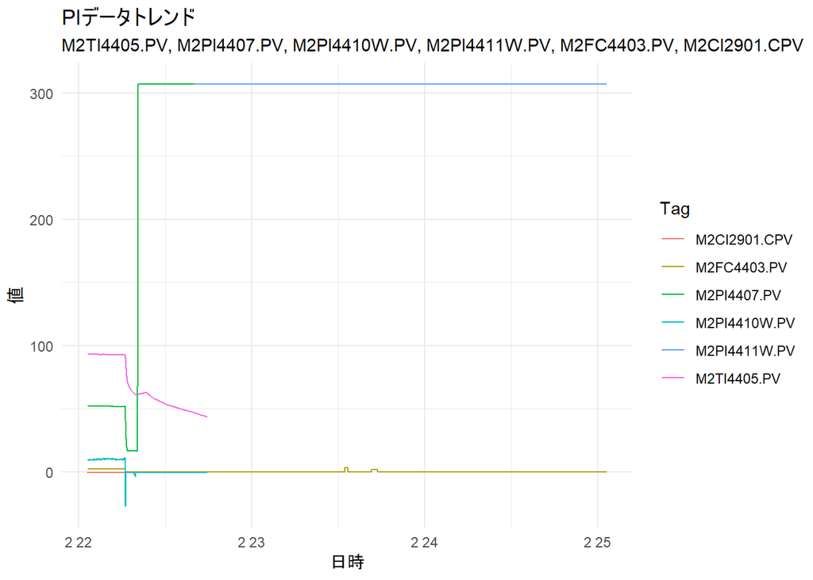

```r
if (nrow(all_data) > 0) {
  # 型変換
  all_data$Timestamp <- ymd_hms(all_data$Timestamp)
  all_data$Value <- as.numeric(all_data$Value)

  # 数値変換でNAになったデータ（システムステート等）を除去
  all_data <- all_data %>% filter(!is.na(Value))

  # プロット
  ggplot(all_data, aes(x = Timestamp, y = Value, color = Tag)) +
    geom_line() +
    labs(title = "PIデータトレンド",
         subtitle = paste(TAG_NAMES, collapse = ", "),
         x = "日時",
         y = "値") +
    theme_minimal()
} else {
  print("表示可能なデータがありません。")
}
```